# Test python installation

This is just a test lab. We strongly encourage you to run it. Most of it should work with no errors (but you may get warnings if you are using quite a different versions of the libraries).

## import libraries

We'll be using many libraries, here we import some of the more common ones.

```python
import pandas as pd
import numpy as np
import matplotlib
import matplotlib.pyplot as plt
import sklearn
from sklearn.neighbors import KNeighborsClassifier
import sys
```

Which versions of programs are we using?

```python
print("Python:", sys.version)
print("pandas:", pd.__version__)
print("numpy:", np.__version__)
print("matplotlib:", matplotlib.__version__)
print("sklearn:", sklearn.__version__)
```

```
Python: 3.11.9 | packaged by conda-forge | (main, Apr 19 2024, 18:36:13) [GCC 12.3.0]
pandas: 2.2.2
numpy: 1.26.4
matplotlib: 3.8.4
sklearn: 1.4.2
```

## First test numpy and matplotlib plotting

You should see a histogram

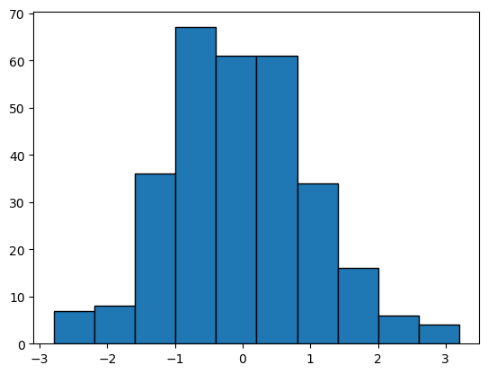

```python
N = 300
x = np.random.normal(size=N)
_ = plt.hist(x, edgecolor="k")
```

## Do we have working pandas?

Pandas is the python data frame library, and we need data frames!

You should see a tiny data frame with two variables, x and y, and their scatterplot where you see the variables are clearly correlated.

```
          x         y
0  0.841835 -0.325237
1  1.166644  3.945475
2 -0.265819  0.086627
3 -0.591911 -1.200361
4 -0.420019 -0.566269
```

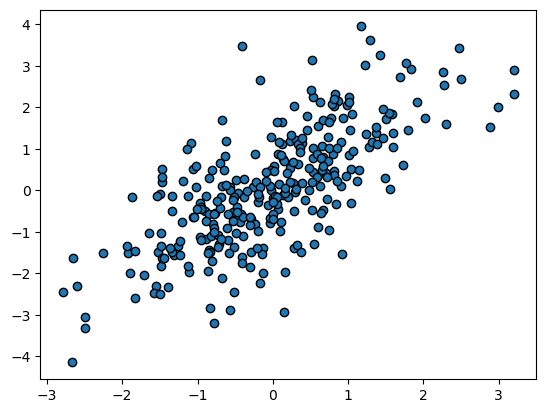

```python
df = pd.DataFrame( {'x':x, 'y': x + np.random.normal(size=N)})
print(df.head())
a = plt.scatter(df.x, df.y, edgecolor='k')
```

## Does sklearn work?

*sklearn* is one of the favorite predictive modeling libraries. Does it work? Let's try a decision boundary plot with nearest neighbors method

You should see a yellow/purple figure with yellow and purple dots. (This is 1-nearest-neighbors' decision boundary plot)

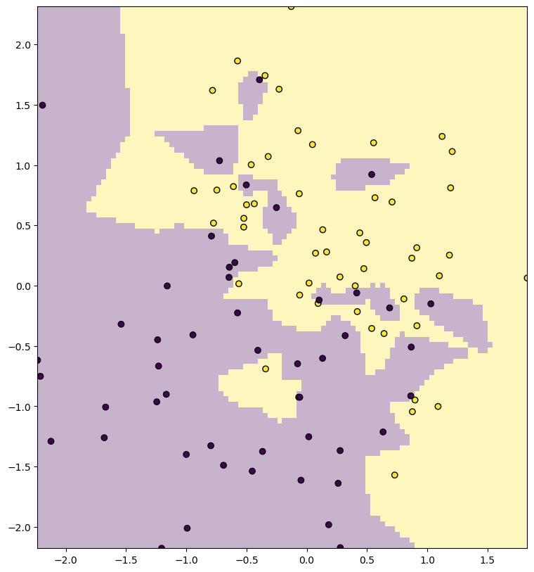

```python
N = 100
X1 = np.random.normal(size=N)
X2 = np.random.normal(size=N)
Y = X1 + X2 + np.random.normal(size=N) > 0
X = np.stack((X1, X2), axis=1)
m = KNeighborsClassifier(n_neighbors=1).fit(X, Y)
## Now greate the regular grid
ex1 = np.linspace(X1.min(), X1.max(), 100)
ex2 = np.linspace(X2.min(), X2.max(), 100)
xx1, xx2 = np.meshgrid(ex1, ex2)
                           # unlike R-s 'expand.grid', meshgrid creates matrices
g = np.stack((xx1.ravel(), xx2.ravel()), axis=1)
                           # we create the design matrix by stacking the xx1, xx2
                           # after unraveling those into columns
## predict on the grid
hatY = m.predict(g).reshape(100,100)
                           # imshow wants a matrix, so we reshape the predicted
                           # vector into one
plt.figure(figsize=(10,10))
ax = plt.subplot(1,1,1)
ax.set_aspect('equal')
ax.imshow(hatY, extent=(X1.min(), X1.max(), X2.min(), X2.max()),
           interpolation='none', origin='lower',
                           # you need to specify that the image begins from below,
                           # not above, otherwise it will be flipped around
           alpha=0.3)
ax.scatter(X1, X2, c=Y, edgecolor='k')
plt.show()
```

## Keras

*keras* is one of the state-of-the-art neural network libraries. This requires a working installation of either tensorflow or pytorch. It normally works well, but people have had issues on M1/M2 macs. We will use it a little bit at the end of the course. If the following fails, no worries for now. On the jupyterhub server, keras is already installed.

In the following we import tensorflow and do a simple neural network task with *keras*. If it is correctly installed, it should work, but you may see warnings regarding missing CUDA (i.e. missing gpu). This is fine.

```python
import keras
print("keras:", keras.__version__)
from keras.models import Sequential
from keras.layers import Dropout, Dense, Input
from keras.utils import to_categorical
from sklearn.model_selection import train_test_split
```

```
keras: 3.3.3
```

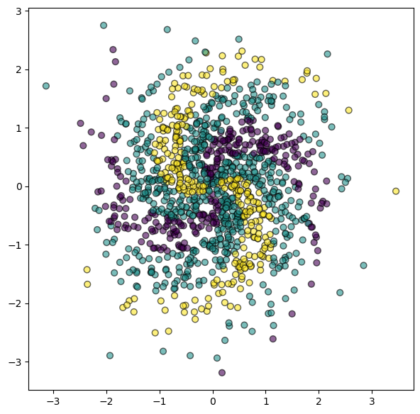

```python
n = 1200  # how many points
x1 = np.random.normal(size=n)
x2 = np.random.normal(size=n)
alpha = np.arctan2(x2, x1)
r = np.sqrt(x1**2 + x2**2)
c1 = (np.sin(2*alpha + 2*r) > 0).astype('int')
c2 = (np.cos(2*alpha + 2*r) > 0).astype('int')
c = c1 + c2  # this is your target
# features, target:
X = np.column_stack((x1,x2))
y = c
# this is how the data looks like:
plt.figure(figsize=(7,7))
plt.scatter(x1, x2, c=c, s=40, edgecolors='k', alpha=0.6)
plt.show()
```

Create the model. Sequential model means that data is sent from the first layers to the following layers, and not backward (as recursive networks do).

```python
model = Sequential()
model.add(Input((2,)))
model.add(Dense(256, activation='relu'))
model.add(Dense(128, activation='relu'))
model.add(Dense(64, activation='relu'))
model.add(Dense(3, activation='softmax'))
model.compile(loss='categorical_crossentropy',
              optimizer='adam',
              metrics=['accuracy'])
model.summary()
```

```
Model: "sequential"
```

```
┏━━━━━━━━━━━━━━━━━━━━━━━━━━━━━━━━━┳━━━━━━━━━━━━━━━━━━━━━━━━┳━━━━━━━━━━━━━━━┓
┃ Layer (type)                    ┃ Output Shape           ┃       Param # ┃
┡━━━━━━━━━━━━━━━━━━━━━━━━━━━━━━━━━╇━━━━━━━━━━━━━━━━━━━━━━━━╇━━━━━━━━━━━━━━━┩
│ dense (Dense)                   │ (None, 256)            │           768 │
├─────────────────────────────────┼────────────────────────┼───────────────┤
│ dense_1 (Dense)                 │ (None, 128)            │        32,896 │
├─────────────────────────────────┼────────────────────────┼───────────────┤
│ dense_2 (Dense)                 │ (None, 64)             │         8,256 │
├─────────────────────────────────┼────────────────────────┼───────────────┤
│ dense_3 (Dense)                 │ (None, 3)              │           195 │
└─────────────────────────────────┴────────────────────────┴───────────────┘
```

```
 Total params: 42,115 (164.51 KB)
```

```
 Trainable params: 42,115 (164.51 KB)
```

```
 Non-trainable params: 0 (0.00 B)
```

Train the model

```python
color = to_categorical(y)  # need one-hot-encoded categoricals
Xt, Xv, colort, colorv = train_test_split(X, color)
## Model Training:
history = model.fit(
    Xt, colort,
    epochs=50,
    validation_data=(Xv, colorv)
)
```

```
29/29 ━━━━━━━━━━━━━━━━━━━━ 2s 11ms/step - accuracy: 0.4400 - loss: 1.0687 - val_accuracy: 0.5267 - val_loss: 0.9980
29/29 ━━━━━━━━━━━━━━━━━━━━ 0s 3ms/step - accuracy: 0.4943 - loss: 1.0097 - val_accuracy: 0.5267 - val_loss: 0.9883
29/29 ━━━━━━━━━━━━━━━━━━━━ 0s 3ms/step - accuracy: 0.5023 - loss: 0.9908 - val_accuracy: 0.5167 - val_loss: 0.9727
29/29 ━━━━━━━━━━━━━━━━━━━━ 0s 3ms/step - accuracy: 0.5257 - loss: 0.9161 - val_accuracy: 0.5100 - val_loss: 0.9739
29/29 ━━━━━━━━━━━━━━━━━━━━ 0s 3ms/step - accuracy: 0.5823 - loss: 0.8994 - val_accuracy: 0.5400 - val_loss: 0.9500
29/29 ━━━━━━━━━━━━━━━━━━━━ 0s 3ms/step - accuracy: 0.5829 - loss: 0.8812 - val_accuracy: 0.5267 - val_loss: 0.9341
29/29 ━━━━━━━━━━━━━━━━━━━━ 0s 3ms/step - accuracy: 0.5976 - loss: 0.8366 - val_accuracy: 0.5933 - val_loss: 0.8993
29/29 ━━━━━━━━━━━━━━━━━━━━ 0s 3ms/step - accuracy: 0.6557 - loss: 0.7859 - val_accuracy: 0.6133 - val_loss: 0.8554
29/29 ━━━━━━━━━━━━━━━━━━━━ 0s 3ms/step - accuracy: 0.6978 - loss: 0.7400 - val_accuracy: 0.6367 - val_loss: 0.7861
29/29 ━━━━━━━━━━━━━━━━━━━━ 0s 3ms/step - accuracy: 0.7268 - loss: 0.6668 - val_accuracy: 0.6700 - val_loss: 0.7422
29/29 ━━━━━━━━━━━━━━━━━━━━ 0s 3ms/step - accuracy: 0.7764 - loss: 0.5965 - val_accuracy: 0.6667 - val_loss: 0.6855
29/29 ━━━━━━━━━━━━━━━━━━━━ 0s 3ms/step - accuracy: 0.7632 - loss: 0.5584 - val_accuracy: 0.7133 - val_loss: 0.6086
29/29 ━━━━━━━━━━━━━━━━━━━━ 0s 3ms/step - accuracy: 0.7871 - loss: 0.5321 - val_accuracy: 0.7867 - val_loss: 0.5951
29/29 ━━━━━━━━━━━━━━━━━━━━ 0s 3ms/step - accuracy: 0.8431 - loss: 0.4728 - val_accuracy: 0.8267 - val_loss: 0.5463
29/29 ━━━━━━━━━━━━━━━━━━━━ 0s 3ms/step - accuracy: 0.8605 - loss: 0.4242 - val_accuracy: 0.7933 - val_loss: 0.5242
29/29 ━━━━━━━━━━━━━━━━━━━━ 0s 3ms/step - accuracy: 0.8519 - loss: 0.4222 - val_accuracy: 0.8467 - val_loss: 0.4758
29/29 ━━━━━━━━━━━━━━━━━━━━ 0s 3ms/step - accuracy: 0.8841 - loss: 0.3653 - val_accuracy: 0.8200 - val_loss: 0.4804
29/29 ━━━━━━━━━━━━━━━━━━━━ 0s 3ms/step - accuracy: 0.8721 - loss: 0.3738 - val_accuracy: 0.8300 - val_loss: 0.4493
29/29 ━━━━━━━━━━━━━━━━━━━━ 0s 3ms/step - accuracy: 0.8578 - loss: 0.3590 - val_accuracy: 0.8567 - val_loss: 0.4112
29/29 ━━━━━━━━━━━━━━━━━━━━ 0s 3ms/step - accuracy: 0.8742 - loss: 0.3234 - val_accuracy: 0.8733 - val_loss: 0.4127
29/29 ━━━━━━━━━━━━━━━━━━━━ 0s 3ms/step - accuracy: 0.8889 - loss: 0.3179 - val_accuracy: 0.8200 - val_loss: 0.4462
29/29 ━━━━━━━━━━━━━━━━━━━━ 0s 3ms/step - accuracy: 0.8813 - loss: 0.2993 - val_accuracy: 0.8667 - val_loss: 0.3855
29/29 ━━━━━━━━━━━━━━━━━━━━ 0s 3ms/step - accuracy: 0.9030 - loss: 0.2863 - val_accuracy: 0.8700 - val_loss: 0.3626
29/29 ━━━━━━━━━━━━━━━━━━━━ 0s 3ms/step - accuracy: 0.8880 - loss: 0.3005 - val_accuracy: 0.8567 - val_loss: 0.3689
29/29 ━━━━━━━━━━━━━━━━━━━━ 0s 3ms/step - accuracy: 0.9068 - loss: 0.2520 - val_accuracy: 0.8733 - val_loss: 0.3719
29/29 ━━━━━━━━━━━━━━━━━━━━ 0s 3ms/step - accuracy: 0.9001 - loss: 0.2716 - val_accuracy: 0.8700 - val_loss: 0.3373
29/29 ━━━━━━━━━━━━━━━━━━━━ 0s 3ms/step - accuracy: 0.8745 - loss: 0.3075 - val_accuracy: 0.9033 - val_loss: 0.3473
29/29 ━━━━━━━━━━━━━━━━━━━━ 0s 3ms/step - accuracy: 0.9182 - loss: 0.2512 - val_accuracy: 0.8967 - val_loss: 0.3415
29/29 ━━━━━━━━━━━━━━━━━━━━ 0s 3ms/step - accuracy: 0.8970 - loss: 0.2487 - val_accuracy: 0.9033 - val_loss: 0.2951
29/29 ━━━━━━━━━━━━━━━━━━━━ 0s 3ms/step - accuracy: 0.9167 - loss: 0.2168 - val_accuracy: 0.8867 - val_loss: 0.2875
29/29 ━━━━━━━━━━━━━━━━━━━━ 0s 3ms/step - accuracy: 0.9127 - loss: 0.2188 - val_accuracy: 0.8900 - val_loss: 0.3485
29/29 ━━━━━━━━━━━━━━━━━━━━ 0s 3ms/step - accuracy: 0.9166 - loss: 0.2160 - val_accuracy: 0.9200 - val_loss: 0.2912
29/29 ━━━━━━━━━━━━━━━━━━━━ 0s 3ms/step - accuracy: 0.9227 - loss: 0.2060 - val_accuracy: 0.8967 - val_loss: 0.3272
29/29 ━━━━━━━━━━━━━━━━━━━━ 0s 3ms/step - accuracy: 0.9410 - loss: 0.1841 - val_accuracy: 0.9167 - val_loss: 0.2943
29/29 ━━━━━━━━━━━━━━━━━━━━ 0s 3ms/step - accuracy: 0.9221 - loss: 0.2047 - val_accuracy: 0.8833 - val_loss: 0.3129
29/29 ━━━━━━━━━━━━━━━━━━━━ 0s 3ms/step - accuracy: 0.9216 - loss: 0.1965 - val_accuracy: 0.9233 - val_loss: 0.2799
29/29 ━━━━━━━━━━━━━━━━━━━━ 0s 3ms/step - accuracy: 0.9341 - loss: 0.1945 - val_accuracy: 0.8633 - val_loss: 0.3607
29/29 ━━━━━━━━━━━━━━━━━━━━ 0s 3ms/step - accuracy: 0.8915 - loss: 0.2266 - val_accuracy: 0.9300 - val_loss: 0.2676
29/29 ━━━━━━━━━━━━━━━━━━━━ 0s 3ms/step - accuracy: 0.9331 - loss: 0.1694 - val_accuracy: 0.9267 - val_loss: 0.2681
29/29 ━━━━━━━━━━━━━━━━━━━━ 0s 3ms/step - accuracy: 0.9491 - loss: 0.1599 - val_accuracy: 0.9233 - val_loss: 0.2656
29/29 ━━━━━━━━━━━━━━━━━━━━ 0s 3ms/step - accuracy: 0.9439 - loss: 0.1571 - val_accuracy: 0.9133 - val_loss: 0.3290
29/29 ━━━━━━━━━━━━━━━━━━━━ 0s 4ms/step - accuracy: 0.9653 - loss: 0.1405 - val_accuracy: 0.8967 - val_loss: 0.2846
29/29 ━━━━━━━━━━━━━━━━━━━━ 0s 3ms/step - accuracy: 0.9407 - loss: 0.1739 - val_accuracy: 0.9000 - val_loss: 0.2873
29/29 ━━━━━━━━━━━━━━━━━━━━ 0s 3ms/step - accuracy: 0.9436 - loss: 0.1685 - val_accuracy: 0.9300 - val_loss: 0.2606
29/29 ━━━━━━━━━━━━━━━━━━━━ 0s 3ms/step - accuracy: 0.9356 - loss: 0.1616 - val_accuracy: 0.9000 - val_loss: 0.2916
29/29 ━━━━━━━━━━━━━━━━━━━━ 0s 3ms/step - accuracy: 0.9386 - loss: 0.1637 - val_accuracy: 0.9333 - val_loss: 0.2314
29/29 ━━━━━━━━━━━━━━━━━━━━ 0s 3ms/step - accuracy: 0.9511 - loss: 0.1480 - val_accuracy: 0.9233 - val_loss: 0.2506
29/29 ━━━━━━━━━━━━━━━━━━━━ 0s 3ms/step - accuracy: 0.9388 - loss: 0.1806 - val_accuracy: 0.9033 - val_loss: 0.2881
29/29 ━━━━━━━━━━━━━━━━━━━━ 0s 3ms/step - accuracy: 0.9449 - loss: 0.1712 - val_accuracy: 0.9233 - val_loss: 0.2497
29/29 ━━━━━━━━━━━━━━━━━━━━ 0s 3ms/step - accuracy: 0.9295 - loss: 0.1738 - val_accuracy: 0.9067 - val_loss: 0.2971
```

Finally, predict and plot the decision boundary. You should see that the predicted (solid color) area captures the data (dots) pretty well but not perfectly.

```
313/313 ━━━━━━━━━━━━━━━━━━━━ 0s 1ms/step
```

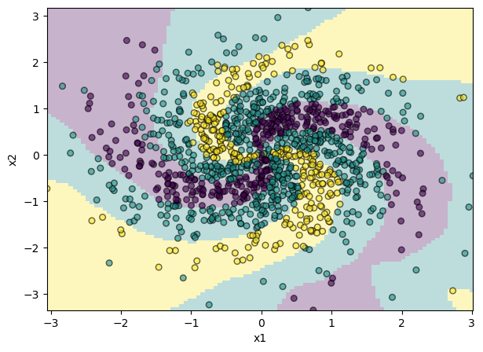

```python
# Predict and plot: take this code as black box
range1 = np.linspace(X[:,0].min(), X[:,0].max(), 100)
range2 = np.linspace(X[:,1].min(), X[:,1].max(), 100)
(xx1, xx2) = np.meshgrid(range1, range2)
Xgrid = np.column_stack((xx1.ravel(), xx2.ravel()))
phat = model.predict(Xgrid)
yhat = np.argmax(phat, axis=-1)
plt.figure(figsize=(7,5))
# plot the predicted values on grid as an image
plt.imshow(yhat.reshape((100,100)),
           alpha=0.3, extent=[xx1.min(), xx1.max(), xx2.min(), xx2.max()],
           origin='lower', aspect='auto')
# add the actual values
plt.scatter(X[:,0], X[:,1], c=y, s=30, alpha=0.6, edgecolor="k")
plt.xlabel("x1")
plt.ylabel("x2")
plt.show()
```